# World Bank Indicators

### Comparison of above metrics of developed, developing and poor countries

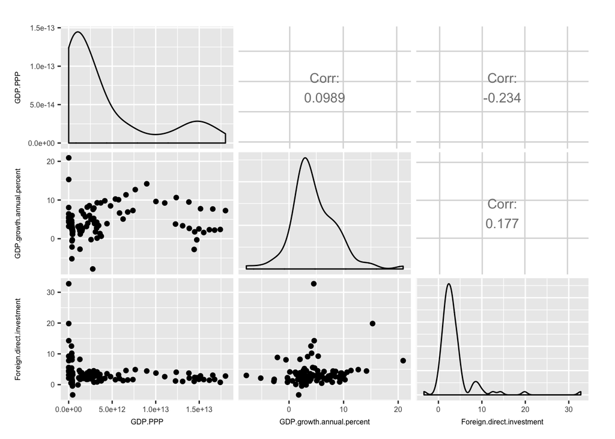

```r
wdiData <- WDI(iso2cNames, indicatorMetaData[c(89,87,10),1], start=2004, end=2014)
names(wdiData)<-c("iso2c","country","year","GDP.PPP","GDP.growth.annual.percent","Foreign.direct.investment")
ggpairs(wdiData,4:6)+ theme(axis.text=element_text(size=6),
        axis.title=element_text(size=6,face="bold"))
```

### Unemployment rate of developed, developing and poor countries

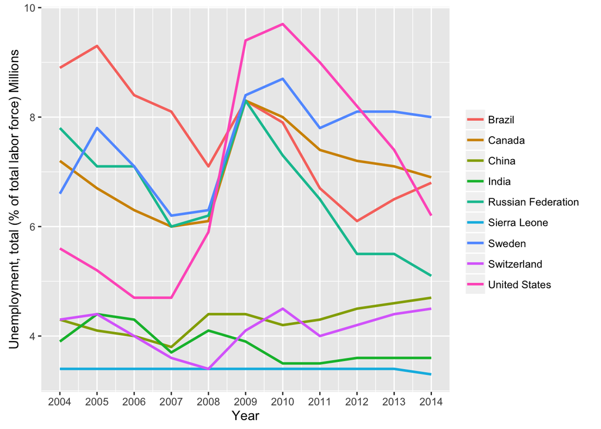

```r
indicatorMetaData <- WDIsearch("Unemployment", field="name", short=FALSE)
wdiData <- WDI(iso2cNames, indicatorMetaData[18,1], start=2004, end=2014)
indicatorName<-indicatorMetaData[18,2]
ggplot(wdiData, aes(x=year, y=(wdiData[,3]),
                     group=country, color=country))+
      geom_line(size=1)+scale_x_continuous(name="Year",
                                          breaks=c(unique(wdiData[,"year"])))+
      scale_y_continuous(name=paste(indicatorName,"Millions"))+
      scale_linetype_discrete(name="Country")+
      theme(legend.title=element_blank())
```

The fluctuation of unemployment rate is acute during the last several years. Affected by the financial crisis in 2008, there is a huge increase in unemployment rate in that year. The United States is one of the worst victims, As we can see in the graph, the unemployment rate of the United States increased the most among all the countries examined.

### Total Population of developed, developing and poor countries

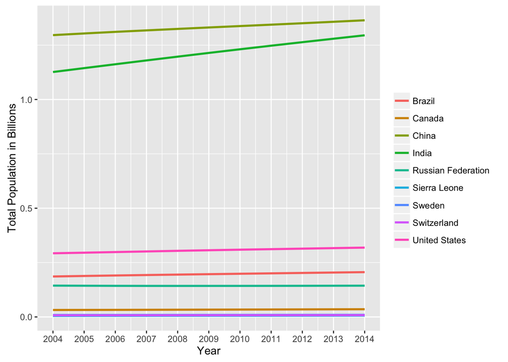

```r
wdiData <- WDI(iso2cNames, indicator="SP.POP.TOTL", start=2004, end=2014)
ggplot(wdiData, aes(x=year, y=(wdiData[,3]/10^9),
                    group=country, color=country))+
     geom_line(size=1)+scale_x_continuous(name="Year",
                                         breaks=c(unique(wdiData[,"year"])))+
     scale_y_continuous(name="Total Population in Billions")+
     scale_linetype_discrete(name="Country")+
     theme(legend.title=element_blank())
```

### Labor Force of developed, developing and poor countries

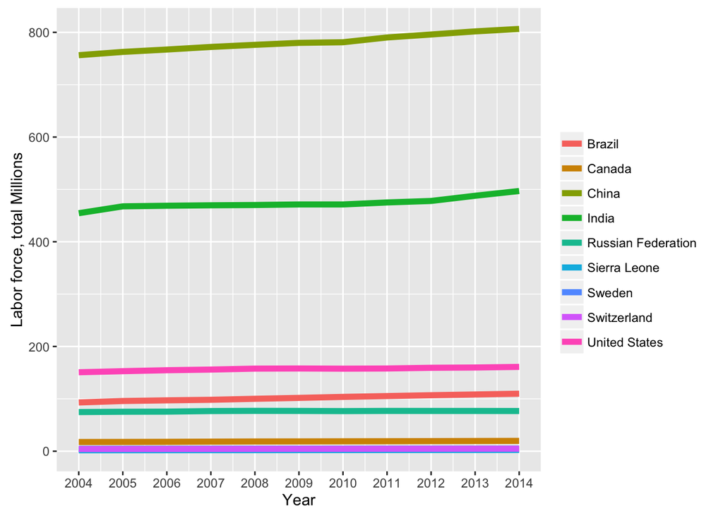

```r
indicatorMetaData <- WDIsearch("Labor", field="name", short=FALSE)
wdiData <- WDI(iso2cNames, indicatorMetaData[53,1], start=2004, end=2014)
indicatorName<-indicatorMetaData[53,2]
ggplot(wdiData, aes(x=year, y=(wdiData[,3]/10^6),
                     group=country, color=country))+
      geom_line(size=2)+scale_x_continuous(name="Year",
                                          breaks=c(unique(wdiData[,"year"])))+
      scale_y_continuous(name=paste(indicatorName,"Millions"))+
      scale_linetype_discrete(name="Country")+
      theme(legend.title=element_blank())
```

This graph looks at the labor strength of the various countries by the millions. China and India have the highest Labor force, followed by the United States. This variable has to be correlated with the population. We will test this out further in the next step.

### Heat Maps to schowcase different metrics for the entire world

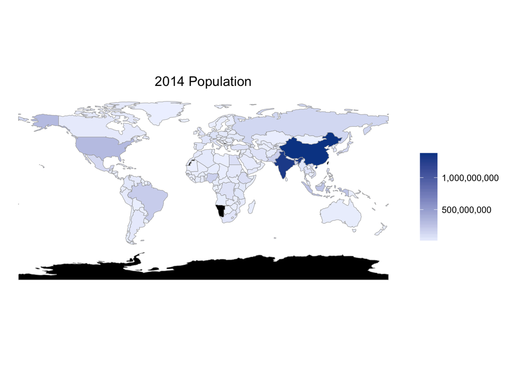

```r
choroplethr_wdi(code="SP.POP.TOTL", year=2014, title="2014 Population", num_colors=1)
```

The allocation of world population is very uneven. Some parts of the world are covered with very light blue, such as Canada and Australia, which means these parts have very a small population. Some countries, such as China and India, are covered with dark blue, which means these two countries have very large population.

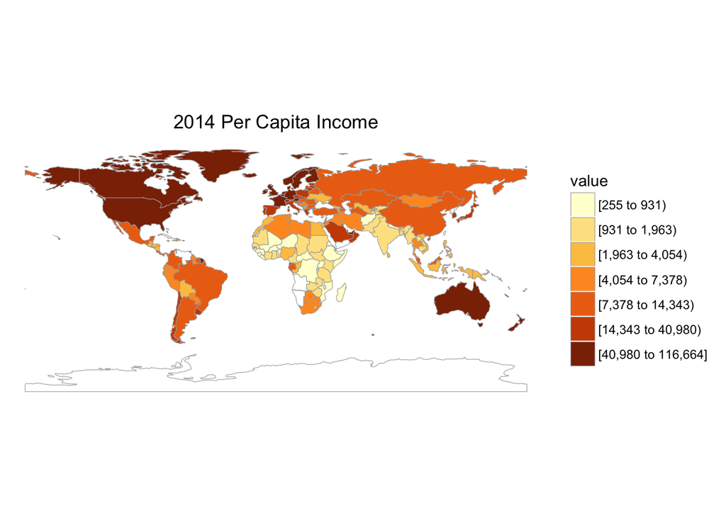

```r
choroplethr_wdi(code="NY.GDP.PCAP.CD", year=2014, title="2014 Per Capita Income") + scale_fill_brewer(palette = "YlOrBr")
```

The highest intensity of Per Capita Income is primarily located in the North America and Western Europe. The less dense is primarily in Asia, Eastern Europe and Latin America. Africa and India has the least Per Capita Income.

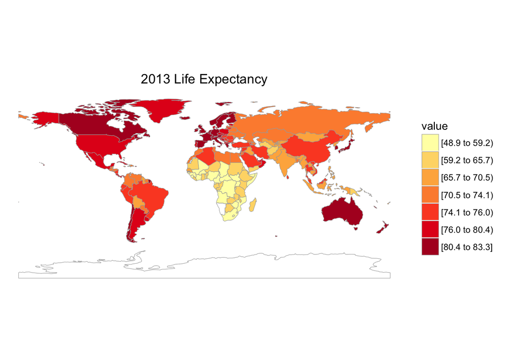

```r
choroplethr_wdi(code="SP.DYN.LE00.IN", year=2013, title="2013 Life Expectancy") + scale_fill_brewer(palette="YlOrRd")
```

The life expectancy is also pretty uneven. The developed countries tend to be covered in darker color, which means these countries have higher life expectancy. The countries in Africa are covered in lighter colors, which means these countries have lower life expectancy.

# Association Rules

```r
library(arules)
indicatorMetaData <- WDIsearch("GDP", field="name", short=FALSE)
countries <- c("United States", "India", "China", "Sweden", "Brazil",
               "Russia","Sierra Leone","Switzerland","Canada")
iso2cNames <- countrycode(countries, "country.name", "iso2c")
wdiData <- WDI(iso2cNames, indicatorMetaData[93,1], start=2004, end=2014)
data2<-wdiData[c(2,3,4)]
wdiData <- WDI(iso2cNames, indicator="SP.DYN.LE00.IN", start=2004, end=2014)
data2<-cbind(data2,wdiData[3])
names(data2)<-c("country","income.per.capita","year","life.expectancy")
data2$income.per.capita<-discretize(data2$income.per.capita,categories = 5,labels = c("<$17k","$17k-35k","$35k-52k","$52k-70k","$70k+"))
data2$life.expectancy<-discretize(data2$life.expectancy,categories = 5,labels = c("42-50 Years","50-60 Years","60-65 Years","65-75 Years","75+ Years"))
data2$country<-sapply(data2$country,as.factor)
data2$year<-sapply(data2$year,as.factor)
rules2 = apriori(data2)
```

```
## Apriori
##
## Parameter specification:
##  confidence minval smax arem  aval originalSupport support minlen maxlen
##         0.8    0.1    1 none FALSE            TRUE     0.1      1     10
##  target   ext
##   rules FALSE
##
## Algorithmic control:
##  filter tree heap memopt load sort verbose
##     0.1 TRUE TRUE  FALSE TRUE    2    TRUE
##
## Absolute minimum support count: 9
##
## set item appearances ...[0 item(s)] done [0.00s].
## set transactions ...[29 item(s), 99 transaction(s)] done [0.00s].
## sorting and recoding items ... [16 item(s)] done [0.00s].
## creating transaction tree ... done [0.00s].
## checking subsets of size 1 2 3 done [0.00s].
## writing ... [23 rule(s)] done [0.00s].
## creating S4 object  ... done [0.00s].
```

```r
inspect(rules2[16])
```

```
##   lhs                             rhs                           support confidence     lift
## 1 {income.per.capita=$52k-70k} => {life.expectancy=75+ Years} 0.1111111  0.8461538 1.861538
```

## Interpretation

Next, we choose 9 countries and related data from 2004 to 2014 to examine if there is any association rules between labor force and total population. In order to do that, we firstly convert numeric variables, labor force and total population, to categorical variables using the cut function. Then the apriori function to develop a set of association rules. Here is the code for it:

```r
wdiData <- WDI(iso2cNames, indicator = c("SL.TLF.TOTL.IN",
                                         "SP.POP.TOTL"),
               start = 2004, end = 2014)
names(wdiData) <- c("Country Code", "Country", "Year",
                    "Labor Force", "Total Population")
wdiData$`Labor Force` <- wdiData$`Labor Force`/10^6
wdiData$`Total Population` <- wdiData$`Total Population`/10^6
wdiData$`Labor Force` <- cut(wdiData$`Labor Force`,
                             breaks = c(0,200,400,600,900), labels = c("<200Mil","200Mil to 400Mil","400Mil to 600Mil",
                                                                                              "600Mil to 900Mil"))
wdiData$`Total Population` <- cut(wdiData$`Total Population`, breaks = c(0,200,400,600,800,1400), labels = c("<200Mil","200Mil to 400Mil",
                                                                                                             "400Mil to 600Mil", "600Mil to 800Mil",
                                                                                                             "800Mil to 1400Mil"))
labor_and_population <- data.frame(wdiData$`Labor Force`,
                                   wdiData$`Total Population`)
rules <- apriori(labor_and_population)
```

```
## Apriori
##
## Parameter specification:
##  confidence minval smax arem  aval originalSupport support minlen maxlen
##         0.8    0.1    1 none FALSE            TRUE     0.1      1     10
##  target   ext
##   rules FALSE
##
## Algorithmic control:
##  filter tree heap memopt load sort verbose
##     0.1 TRUE TRUE  FALSE TRUE    2    TRUE
##
## Absolute minimum support count: 9
##
## set item appearances ...[0 item(s)] done [0.00s].
## set transactions ...[6 item(s), 99 transaction(s)] done [0.00s].
## sorting and recoding items ... [6 item(s)] done [0.00s].
## creating transaction tree ... done [0.00s].
## checking subsets of size 1 2 done [0.00s].
## writing ... [5 rule(s)] done [0.00s].
## creating S4 object  ... done [0.00s].
```

lhs rhs support confidence lift 1 {wdiData..Labor.Force.=600Mil to 900Mil} => {wdiData..Total.Population.=800Mil to 1400Mil} 0.1111111 1.0000000 4.500000 2 {wdiData..Labor.Force.=400Mil to 600Mil} => {wdiData..Total.Population.=800Mil to 1400Mil} 0.1111111 1.0000000 4.500000 3 {wdiData..Total.Population.=200Mil to 400Mil} => {wdiData..Labor.Force.=<200Mil} 0.1515152 1.0000000 1.285714 4 {wdiData..Total.Population.=<200Mil} => {wdiData..Labor.Force.=<200Mil} 0.6262626 1.0000000 1.285714 5 {wdiData..Labor.Force.=<200Mil} => {wdiData..Total.Population.=<200Mil} 0.6262626 0.8051948 1.285714